# Working pipeline

## 1) Import data.

Source data should have a column with speaker identifiers (e.g., usernames) and one with text (e.g., social media posts)

```r
library(tidyverse)
Sys.unsetenv("GITHUB_PAT")
devtools::install_github("davidemorselli/speakerlandscapes", force = TRUE)
library(speakerlandscapes)

data = read_csv2("raw_corpus.csv")
```

```
## ℹ Using "','" as decimal and "'.'" as grouping mark. Use `read_delim()` for more control.
```

```r
head(data)
```

| text | speaker | opinion |
| --- | --- | --- |
| The latest report on extreme weather events is a chilling reminder: we must accelerate the transition to renewables immediately. #ClimateActionNow #Renewables | @GreenFutureNow83 | Pro-Climate |
| We need global cooperation to tackle this crisis, not just individual efforts. Policy makers, step up! #ActOnClimate | @PolicyForChange17 | Pro-Climate |
| Solar and wind energy are already cheaper than fossil fuels in many regions. The technology is here, the will needs to follow. #GreenTech | @SolarPunkFan63 | Pro-Climate |
| Just saw a massive protest by young people demanding action. Their future is at stake, we owe them more than rhetoric. #ClimateYouth | @OurEarth_Now86 | Pro-Climate |
| Divesting from fossil fuels isn't just ethical, it's smart economics. The transition is inevitable. #ESG #DivestNow | @ZeroCarbonJoe7 | Pro-Climate |
| Every fraction of a degree matters. We can't afford complacency or delay. Urgency is key! #ClimateEmergency | @PlanetProtector81 | Pro-Climate |

## 2) Make data ready to build landscapes.

```r
ready_data = prepare_data(data,
                          speaker_id_column = "speaker",
                          text_column = "text",
                          speaker_identifier = "agent")

head(ready_data)
```

```
## [1] "agent_@greenfuturenow83 The latest report on extreme weather events is a chilling reminder we must accelerate the transition to renewables immediately #ClimateActionNow #Renewables"
## [2] "agent_@policyforchange17 We need global cooperation to tackle this crisis not just individual efforts Policy makers step up #ActOnClimate"
## [3] "agent_@solarpunkfan63 Solar and wind energy are already cheaper than fossil fuels in many regions The technology is here the will needs to follow #GreenTech"
## [4] "agent_@ourearth_now86 Just saw a massive protest by young people demanding action Their future is at stake we owe them more than rhetoric #ClimateYouth"
## [5] "agent_@zerocarbonjoe7 Divesting from fossil fuels isn t just ethical it s smart economics The transition is inevitable #ESG #DivestNow"
## [6] "agent_@planetprotector81 Every fraction of a degree matters We can t afford complacency or delay Urgency is key #ClimateEmergency"
```

## 3) Make the embedding

Compute the embeddings from the `speakers_text` object.

```r
embedding = train_embedding_model(ready_data,
                                  min_count = 1,  # Beware, min_count=1 is only for the example. It indicates the minimum frequency required for a token to be included in the vocabulary. A higher number is preferable.
                                  stopwords_language = "en")
```

```
## Starting preprocessing data
```

```
## Making bigrams.....please wait.....
```

```
## Making trigrams.....please wait.....
```

```
## Preparing data for embedding.....
```

```
## Starting Word2Vec model training...this might take a while, sit tight and have a cup of tea!
```

```
## Word2Vec model successfully saved to: embeddings.emb
```

```r
# Validate ! Validate ! Validate !
# check embeddign by exracting simialr words to seed words
library(word2vec)
similar_words = predict(embedding, c("natural","protest"), type = "nearest", top_n = 10)

similar_words
```

```
## $natural
##      term1                term2 similarity rank
## 1  natural            influence  0.9152178    1
## 2  natural agent_@naturalcycle9  0.9149109    2
## 3  natural              factors  0.9144503    3
## 4  natural              forests  0.9109412    4
## 5  natural         oscillations  0.9108821    5
## 6  natural            #wetlands  0.9062353    6
## 7  natural                ocean  0.8990394    7
## 8  natural                sinks  0.8985752    8
## 9  natural          variability  0.8950456    9
## 10 natural            peatlands  0.8927046   10
##
## $protest
##      term1                 term2 similarity rank
## 1  protest agent_@ourearth_now86  0.9798523    1
## 2  protest                   saw  0.9681903    2
## 3  protest             demanding  0.9584374    3
## 4  protest                  live  0.9489377    4
## 5  protest              lavishly  0.9441777    5
## 6  protest              #elitism  0.9395320    6
## 7  protest                action  0.9366425    7
## 8  protest                 young  0.9350707    8
## 9  protest             lifestyle  0.9340329    9
## 10 protest agent_@climateyouth80  0.9330438   10
```

# 4) Make the speaker landscape.

This step uses UMAP to reduce the 250-dimension embedding to a more interpretable 2-dimension space and extract speaker vectors.

```r
landscape = make_speaker_landscapes(data = ready_data,
                                    embedding = embedding,
                                    speaker_identifier = "agent",
                                    retain_threshold = 1,
                                    n_neighbors = 30,
                                    min_dist = 0.01)
```

```
## Number of speakers in training set: 363
```

```
## Number of speakers with at least 1 texts: 363
```

```
## Starting UMAP dimensionality reduction. This might take a while...
```

## 5) Plot the speaker landscape.

Plot the speaker landscape along with word tokens extracted using `get_most_frequent_tokens()`.

```r
frequent_words = get_most_frequent_tokens(ready_data, min_count = 10, stopwords_language = "en")
```

```
## Making bigrams.....please wait.....
```

```
## Making trigrams.....please wait.....
```

```
## Preparing data for embedding.....
```

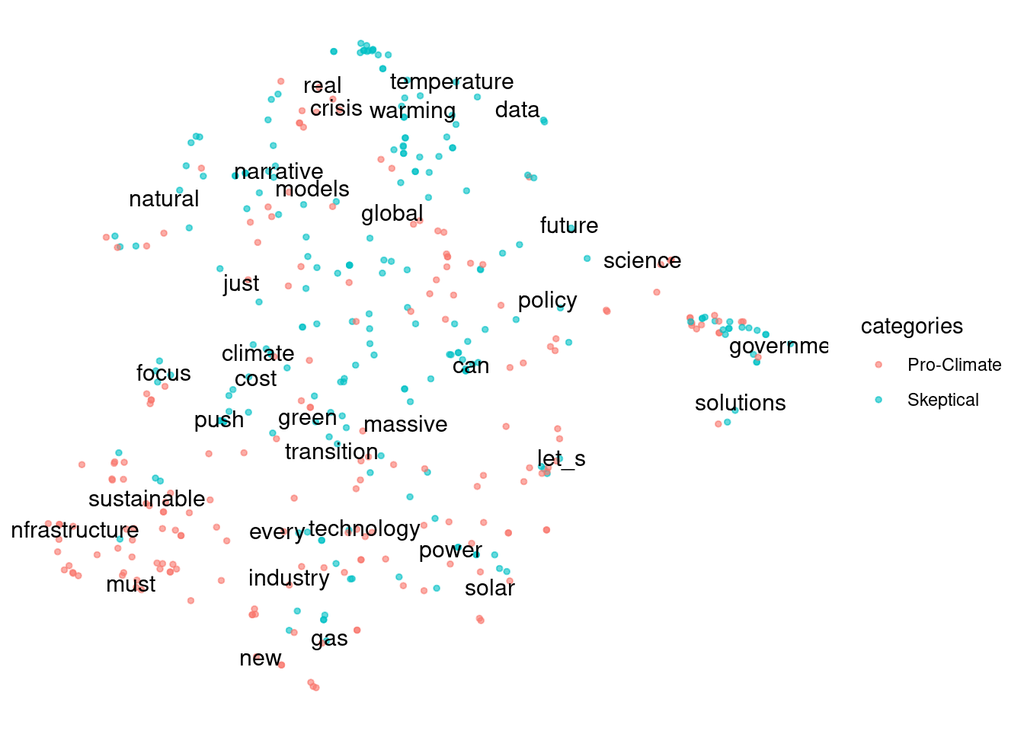

```r
categories = data %>%
  select(speaker, opinion) %>%
  rename(author = speaker,
         categories = opinion) %>%
  mutate(author = tolower(paste0("agent_", author)))

plot_speaker_landscapes(landscape,
                        tokens_to_plot = frequent_words,
                        alpha_points = .6, size_points = 1,
                        categories = categories)
```

## 6) Interactive landscape with click-to-view speaker texts

You can inspect what individual speakers said by clicking on their dots in an interactive visualization. Use `plot_speaker_landscapes(..., interactive = TRUE)` or call `plot_interactive_landscape()` directly:

```r
# Click on any speaker dot to see their original texts in the inspector side panel
plot_speaker_landscapes(landscape,
                        tokens_to_plot = frequent_words,
                        categories = categories,
                        interactive = TRUE)
```

[interactive chart not shown]

## 7) Coloring speakers by normalized cosine proximity to a dictionary centroid

You can project a thematic concept (e.g., anger, climate, optimism) into the embedding space by calculating the centroid of its dictionary tokens, and visualize speakers colored by their **cosine proximity** (where higher values = stronger alignment with the concept).

```r
# 1. Define a dictionary of concept tokens
anger_dict <- c("attack", "punish", "enemy", "harshly", "blackmail", "crush", "ridiculous", "arrogant")

# 2. Compute the dictionary centroid in embedding space
centroid <- compute_dictionary_centroid(anger_dict, embedding)
```

```
## Dictionary tokens matched: 8 of 8 (100.0%).
```

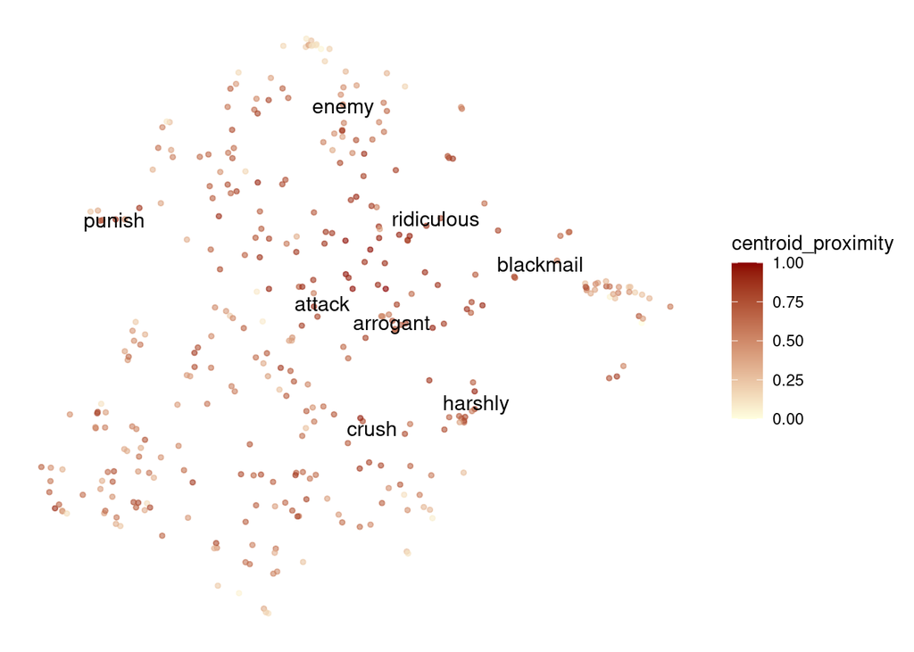

```r
# 3. Plot colored by cosine proximity with custom legend title
plot_speaker_landscapes(landscape,
                         tokens_to_plot = anger_dict,
                         centroid = centroid,
                         embedding = embedding,
                         proximity_palette = c("lightyellow", "darkred"),
                         interactive = FALSE)
```

## 8) Extracting and plotting speaker clusters with HDBSCAN

You can identify density-based clusters of speakers on the 2D landscape using `extract_speaker_clusters()` (powered by `dbscan::hdbscan()`), and plot the clusters on the landscape. `minPts` (minimum size) is the parameter that controls how conservative or sensitive the clustering is to noise. It controls how clusters are formed and how much data gets thrown out as noise. High values (e.g., minPts = 10) are recommended in noisy datasets (like word embeddings or text) where you only want the most definitive clusters.

```r
# 1. Extract speaker clusters using HDBSCAN
landscape <- extract_speaker_clusters(landscape, minPts = 10)
```

```
## HDBSCAN found 9 clusters across 363 speakers (145 noise points).
```

```r
landscape$clusters
```

| cluster | cluster_label | n_speakers | center_x | center_y | mean_dist | sd_dist | max_dist | radius |
| --- | --- | --- | --- | --- | --- | --- | --- | --- |
| 1 | Cluster 1 | 28 | 3.65134654 | 0.5862720 | 0.3395521 | 0.2674213 | 1.1962099 | 0.8609894 |
| 2 | Cluster 2 | 48 | -2.39332221 | -2.5791508 | 0.7011246 | 0.3249916 | 1.6875785 | 1.1999651 |
| 3 | Cluster 3 | 13 | 1.79920647 | -1.4870409 | 0.2360182 | 0.1900634 | 0.6263403 | 0.6173806 |
| 4 | Cluster 4 | 32 | 0.07658533 | -3.0291807 | 0.7955215 | 0.3799444 | 1.3653124 | 1.3860811 |
| 5 | Cluster 5 | 16 | 0.48850180 | 3.2589519 | 0.3182186 | 0.1597128 | 0.6668416 | 0.5906751 |
| 6 | Cluster 6 | 14 | 0.02627801 | 4.7331138 | 0.1633804 | 0.1459887 | 0.5516799 | 0.4637201 |
| 7 | Cluster 7 | 23 | -0.35194218 | -0.8616267 | 0.5838844 | 0.3335103 | 1.3703105 | 1.1665499 |
| 8 | Cluster 8 | 11 | -1.05386811 | 2.5110708 | 0.3269287 | 0.1622028 | 0.6424183 | 0.5962742 |
| 9 | Cluster 9 | 33 | 0.63662430 | 0.8634025 | 0.7489926 | 0.3093575 | 1.4792014 | 1.2435078 |

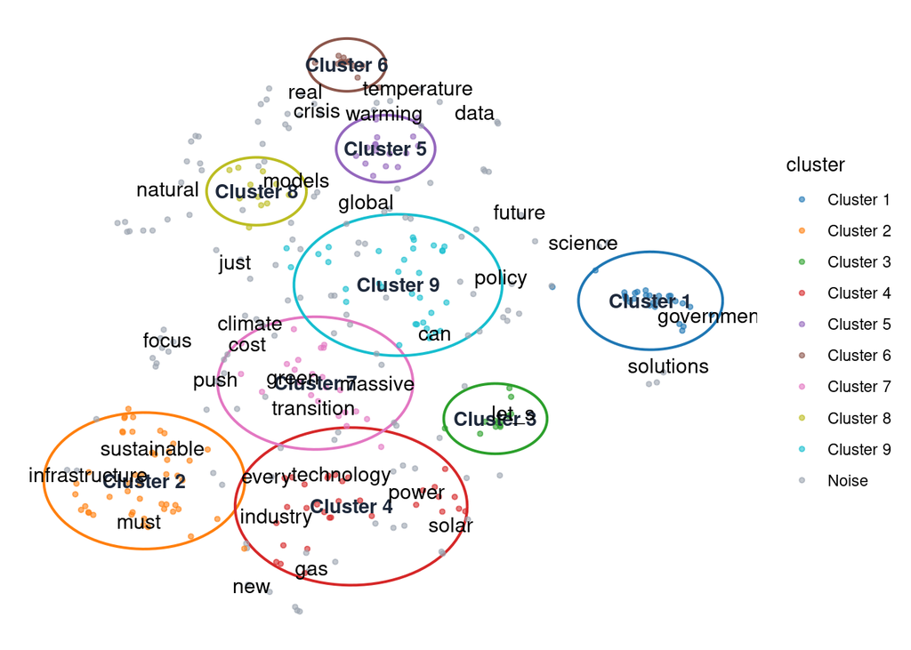

```r
# 2. Static landscape plot with cluster circles
plot_speaker_landscapes(landscape,
                        tokens_to_plot = frequent_words,
                        show_clusters = TRUE,
                        label_clusters = TRUE)
```

```r
# 3. Interactive landscape plot with cluster circles
plot_speaker_landscapes(landscape,
                          tokens_to_plot = frequent_words,
                          show_clusters = TRUE,
                          label_clusters = TRUE,
                         interactive = TRUE)
```

## 9) Calculating proximity between cluster and dictionary centroids

You can measure how semantically aligned each speaker cluster is to a thematic dictionary concept (such as anger or climate tokens) using `calculate_cluster_centroid_proximity()` (or `calculate_cluster_centroid_distance()`). It shows you the cosine similarity and the Euclidean distance between the cluster centroide and the thematic concept.

```r
# Calculate normalized cosine proximity between cluster centroids and the anger dictionary centroid
cluster_proximity <- calculate_cluster_centroid_proximity(
  speaker_landscape = landscape,
  centroid = centroid,
  embedding = embedding,
  space = "both"
)

cluster_proximity %>%
  select(cluster_label,n_speakers,cosine_similarity,dist_2d)
```

| cluster_label | n_speakers | cosine_similarity | dist_2d |
| --- | --- | --- | --- |
| Cluster 1 | 28 | 0.8615323 | 2.895945 |
| Cluster 2 | 48 | 0.8882249 | 4.573760 |
| Cluster 3 | 13 | 0.9262555 | 2.453007 |
| Cluster 4 | 32 | 0.9374174 | 3.825170 |
| Cluster 5 | 16 | 0.9083947 | 2.538837 |
| Cluster 6 | 14 | 0.7599266 | 4.065143 |
| Cluster 7 | 23 | 0.9163376 | 1.944876 |
| Cluster 8 | 11 | 0.9276741 | 2.538329 |
| Cluster 9 | 33 | 0.9815090 | 0.177816 |